# Jóvenes que no estudian ni trabajan en el Perú, 2015-2025

Trabajo final · Fundamentos de R

Grupo 7: Luis Guevara, Rodrigo Norabuena y Marco Virú

4 de octubre de 2026

## La pregunta

> **¿Cómo evolucionó la proporción de jóvenes peruanos de 15 a 29 años que no estudian ni trabajan entre 2015 y 2025, y en qué grupos se concentra esta condición?**

**Por qué importa.** La inactividad juvenil deja cicatrices medibles: en América Latina, un punto porcentual más de ninis en una cohorte de 15 a 20 años se asocia con salarios **7,7 % más bajos entre los varones y 3,0 % entre las mujeres** cuando esa cohorte llega a los 35 a 40 años (Székely & Karver, 2021). En agregado, es capacidad productiva que el país no usa. Es el indicador **8.6.1 de los ODS** (Naciones Unidas, 2015).

El tramo de 15 a 29 años es el que define como *joven* la Ley N.º 27802 (Congreso de la República del Perú, 2002). El indicador de los ODS usa 15 a 24 años: lo reportamos como análisis de robustez. Ya en 2011, Chacaltana & Ruiz (2012) estimaban un 16 % de jóvenes en esta condición con la Encuesta Nacional de la Juventud.

## Nini no es lo mismo que desempleado

### Definición operativa

Persona de **15 a 29 años**, residente habitual del hogar, que cumple las dos condiciones a la vez:

1. **No estudia** — no matriculada en el año en curso, o matriculada pero sin asistir (`p306 ≠ 1` o `p307 ≠ 1`).
2. **No trabaja** — no ocupada según el indicador oficial de la PEA (`ocu500 ≠ 1`), definición del INEI que sigue a la OIT (1982).

### La distinción que cambia todo

El **desempleado** está en la PEA y busca trabajo activamente. El **nini** abarca a los desocupados *y* a los inactivos.

En el Perú la distinción pesa más que en otros países: desde 2005 la participación y la PEA ocupada se mueven en paralelo, porque el **sector informal absorbe a quienes entran** (Asencios et al., 2025). Quedarse fuera no se ve como desempleo, sino como inactividad.

Esa diferencia es el eje de la interpretación, y lo adelantamos: solo 22,9 % de los jóvenes nini está buscando trabajo.

## Los datos: ENAHO 2014-2025

- **Fuente:** Encuesta Nacional de Hogares, INEI (2026). Muestra probabilística, estratificada y bietápica.
- **Unidad de análisis:** la persona residente habitual del hogar.
- **Cobertura:** nacional, urbana y rural, 24 departamentos y el Callao.
- **12 años × 3 módulos = 36 archivos** (`200` miembros, `300` educación, `500` empleo), 693 MB de archivos comprimidos.
- **Ponderación:** `fac500a`, el factor del módulo de empleo, con el **diseño muestral complejo** declarado en `srvyr` (conglomerado × año como unidad primaria).

Tabla 1

|  | Casos | % del anterior |
| --- | --- | --- |
| 1. Personas en el módulo de miembros del hogar | 1 512 409 | — |
| 2. Residentes habituales del hogar | 1 403 132 | 92,8 |
| 3. Residentes habituales de 15 a 29 años | 306 576 | 21,8 |
| 4. Con información válida de educación y empleo (muestra analítica) | 305 906 | 99,8 |

Acumulado de los doce años.

305 906 jóvenes-año en la muestra analítica.

## El dato no viene limpio

### Tres trampas al leer los ZIP

1. **Tamaño.** El módulo de empleo de 2025 pesa 909 MB y tiene 1 413 columnas, porque el INEI pasó al formato Stata 118. Sin `col_select` al leer, **el proceso no corre**.
2. **Estructura inconsistente.** 2015 usa guion bajo en la carpeta interna y en el módulo 03 deja el `.dta` en la raíz. El patrón se ancla al **nombre del archivo**, no a la carpeta.
3. **Archivos que no buscamos.** Clasificadores, complementarios y un duplicado del módulo 500 en 2015: un `*.dta` traería entre dos y cinco archivos por ZIP.

### ¿Significan lo mismo en doce años?

No lo dimos por supuesto: auditamos las **etiquetas de Stata de los 36 archivos**.

**Las tres variables que definen el indicador —`ocu500`, `p306` y `p307`— son idénticas en los doce años**, así que la serie no necesita armonización.

- `p313` y `p546` cambian de redacción, no de códigos.
- `p203` (2018), `p301a` (2017) y `t313a` (2020) suman códigos nuevos: las agrupaciones los absorben.
- Protección extra: **recodificamos por texto de etiqueta, no por número**. Si el INEI renumerara, el reporte falla de forma ruidosa en vez de asignar mal en silencio.

## La trampa de las vacaciones escolares

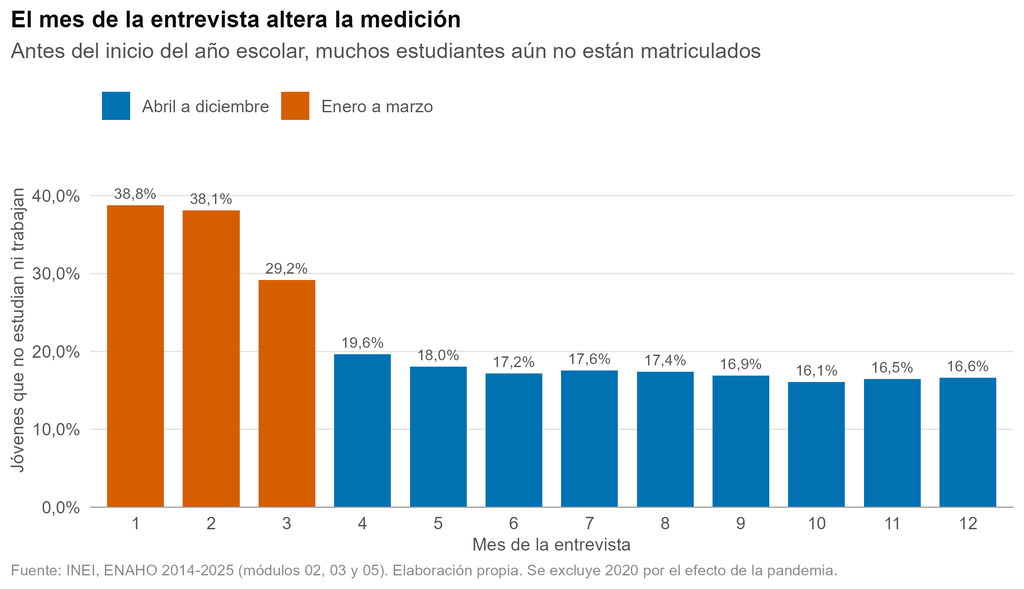

El año escolar peruano empieza en marzo: quien responde en enero dice con sinceridad que «este año» todavía no está matriculado. **Lo corregimos reclasificando como estudiante a quien declara estar de vacaciones** —categoría con el mismo código en los doce años— en lugar de descartar el primer trimestre y perder un cuarto de la muestra.

# Resultados

## La década terminó donde empezó

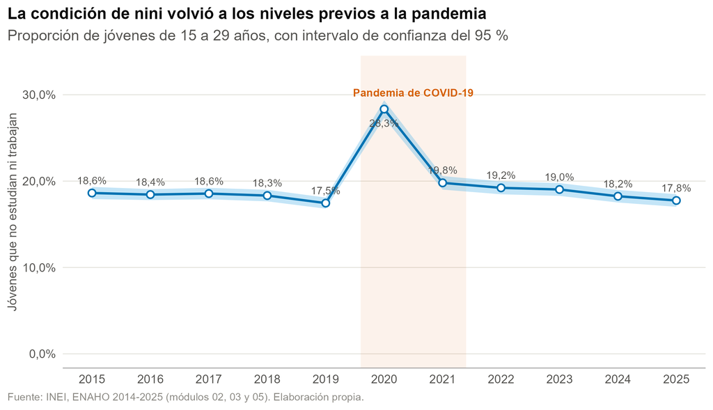

Mejora lenta de 18,6 % (2015) a 17,5 % (2019); **ruptura en 2020**, con 28,3 % —10,9 puntos más, unos 982 mil jóvenes adicionales—; y cinco años de recuperación hasta 17,8 % en 2025. Incluso en el mejor año de la serie, **alrededor de uno de cada seis jóvenes**: cerca de 1,52 millones de personas.

## …y el cambio de la década no es significativo

Tabla 2

| Comparación | Diferencia | IC inf. | IC sup. | *p* |
| --- | --- | --- | --- | --- |
| 2015 a 2019 | −1,17 | −2,13 | −0,21 | ,017 |
| 2019 a 2020 | 10,88 | 9,68 | 12,09 | < ,001 |
| 2020 a 2021 | −8,54 | −9,83 | −7,25 | < ,001 |
| 2019 a 2025 | 0,30 | −0,67 | 1,28 | ,544 |
| 2015 a 2025 | −0,87 | −1,89 | 0,15 | ,095 |
| 2024 a 2025 | −0,49 | −1,52 | 0,54 | ,348 |

Diferencia en puntos porcentuales, estimada con survey::svyglm sobre el diseño muestral complejo.

El salto de 2019 a 2020 y la caída de 2020 a 2021 son, por lejos, los movimientos más grandes de la serie. Pero la comparación que resume la década —**2015 contra 2025**— da apenas 0,9 puntos de descenso y **no alcanza significancia estadística** (*p* = ,095). Después de once años y de una pandemia, no podemos afirmar que el país esté mejor que al inicio de la serie.

## 2020 no fue «más ninis»: fue menos empleo

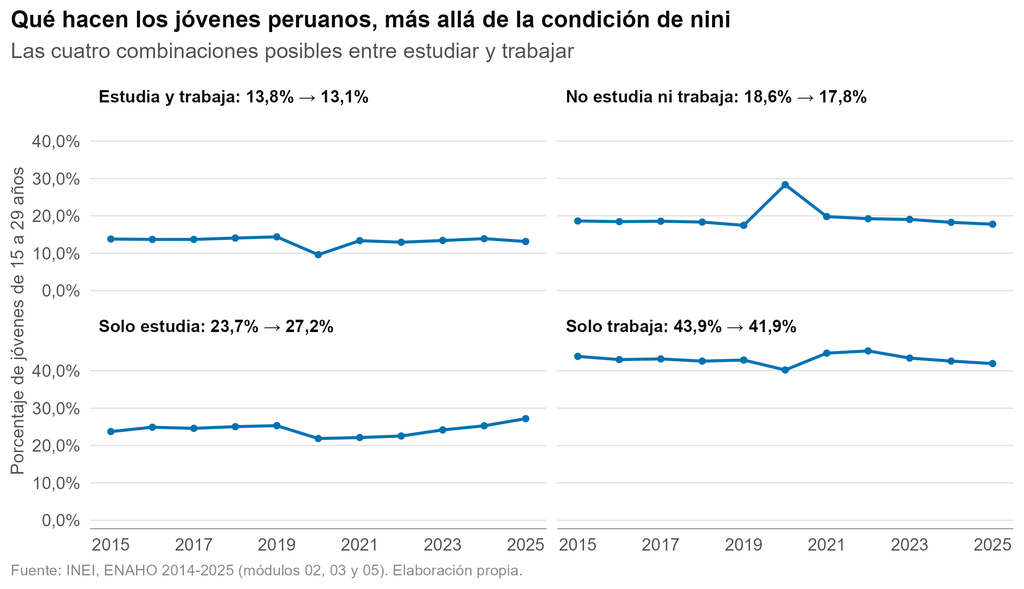

## La brecha de género es el rasgo más persistente

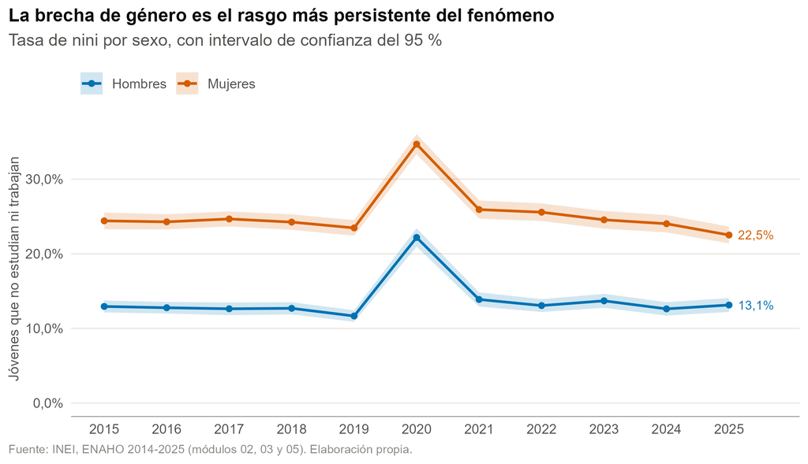

En 2025 la tasa femenina es 22,5 % y la masculina 13,1 %: 9,4 puntos de brecha, frente a 11,5 en 2015. Una década sin tendencia, y **la pandemia la ensanchó en lugar de cerrarla**. El descenso de 2025 es el mejor registro de la serie, pero es **un solo año**: habrá que mirar 2026.

## ¿En qué grupos se concentra?

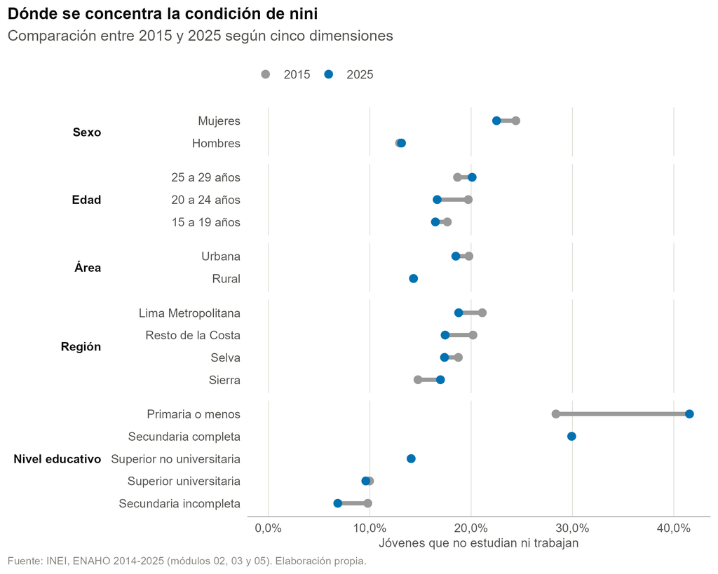

**El sexo domina sobre cualquier otra dimensión:** la diferencia entre mujeres y hombres (9,4 p.p.) es mayor que la que separa a cualquier par de regiones o de áreas.

- **25 a 29 años** es el único grupo de edad que empeoró (1,4 p.p.), mientras 20 a 24 mejoró con claridad.
- La **Sierra** es la única región que retrocedió (2,2 p.p.).

«Primaria o menos» sube con fuerza, pero es un grupo que se achica año a año conforme se expande la cobertura educativa: lo que aumenta es su desventaja relativa, no necesariamente el riesgo de cada persona.

## El nivel educativo hay que leerlo por edad

Tabla 3

| Nivel educativo alcanzado | 15 a 19 años | 20 a 24 años | 25 a 29 años |
| --- | --- | --- | --- |
| Primaria o menos | 46,0 | 39,6 | 40,7 |
| Secundaria incompleta | 2,7 | 21,0 | 27,2 |
| Secundaria completa | 41,9 | 25,3 | 22,9 |
| Superior no universitaria | 3,1 | 13,1 | 17,3 |
| Superior universitaria | 4,1 | 7,2 | 13,4 |

Tasa de nini (%) por nivel educativo alcanzado y grupo de edad, 2025. El nivel de quien aún estudia está en curso, no completo.

«Secundaria incompleta» parece protectora —2,7 % a los 15-19 años— pero es un espejismo: esos jóvenes **siguen cursándola**. Dentro de los **25 a 29 años**, donde la trayectoria educativa ya terminó, aparece el gradiente limpio y monótono: de 40,7 % con primaria o menos a 13,4 % con universidad completa. **La educación superior reduce a menos de un tercio la probabilidad de estar en esta condición.**

## No es desempleo: es trabajo de cuidados

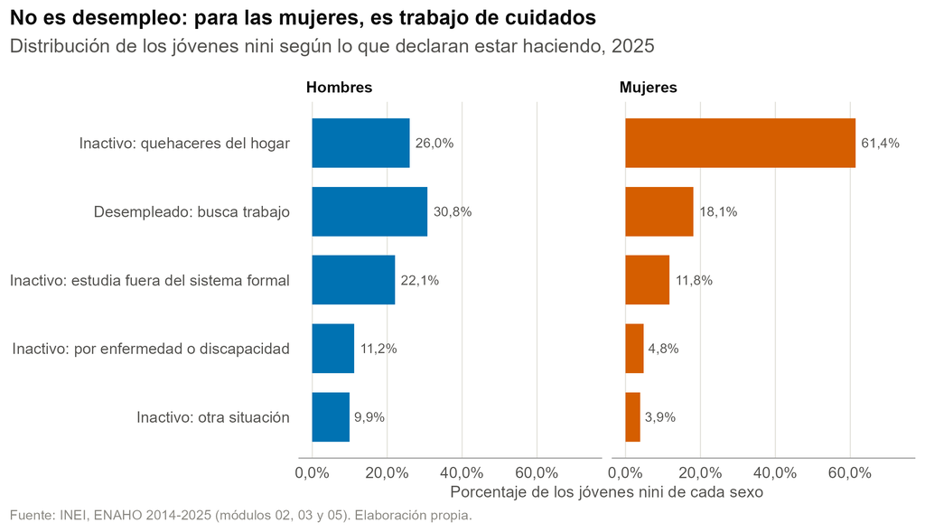

Solo el 22,9 % de los jóvenes nini busca trabajo activamente; el 48,1 % se dedica a los **quehaceres del hogar**. Y ese promedio esconde la asimetría: 61,4 % entre las mujeres nini frente a 26,0 % entre los hombres. **La brecha de género no es principalmente un problema de demanda de empleo, sino de distribución del trabajo de cuidados:** una política centrada solo en intermediación laboral difícilmente la mueva.

## El territorio no sigue al mapa de la pobreza

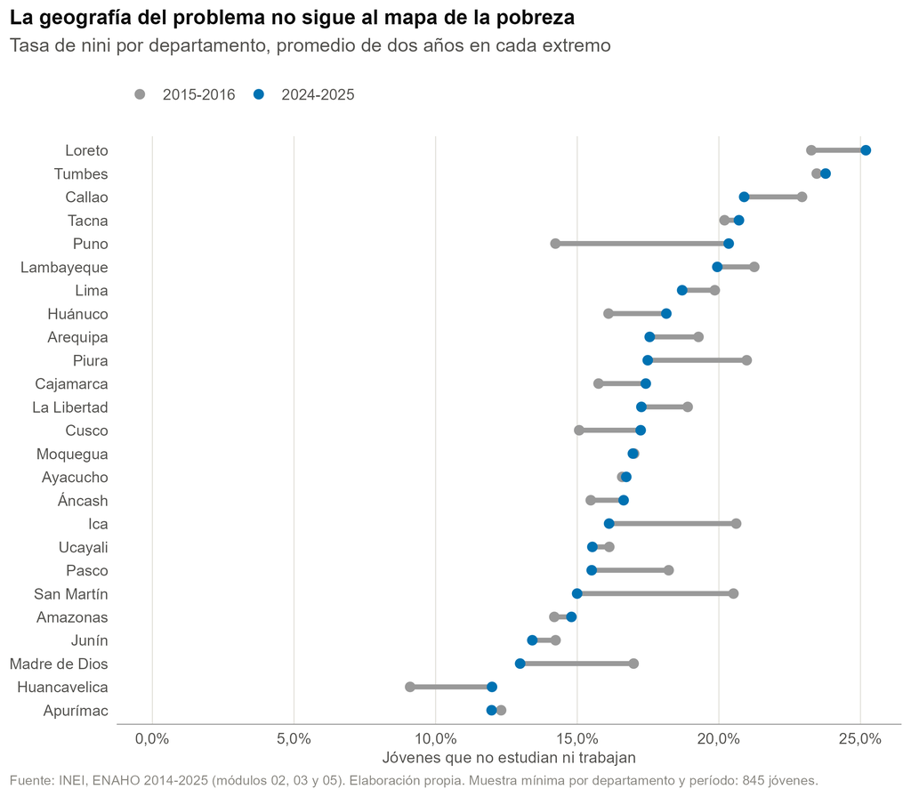

**Tasas más altas (2024-2025):** Loreto, Tumbes, Callao.

**Más bajas:** Apurímac, Huancavelica, Madre de Dios, que incluyen dos de los departamentos más pobres del país.

La lectura tentadora —que la pobreza «protege»— es falsa. En las economías rurales de subsistencia los jóvenes se incorporan temprano al trabajo agrícola o familiar, muchas veces sin remuneración, y el indicador los cuenta como ocupados. **Una tasa baja no significa bienestar.**

Con muestras departamentales de alrededor de mil jóvenes por período, estas cifras son señales, no mediciones finas.

## Robustez: la forma de la serie no cambia

Tabla 4

| Año | Principal | Sin corregir vacaciones | Solo abril a diciembre | 15 a 24 años (ODS 8.6.1) | Excluye capacitación | Estudia = solo matriculado |
| --- | --- | --- | --- | --- | --- | --- |
| 2015 | 18,6 | 21,3 | 17,6 | 18,6 | 15,3 | 18,2 |
| 2019 | 17,5 | 20,9 | 16,0 | 16,6 | 14,3 | 17,1 |
| 2020 | 28,3 | 32,1 | 30,0 | 27,2 | 26,1 | 26,5 |
| 2024 | 18,2 | 21,5 | 17,2 | 17,2 | 15,2 | 17,7 |
| 2025 | 17,8 | 21,3 | 16,5 | 16,6 | 14,9 | 17,1 |

Tasa de nini (%) bajo seis criterios alternativos. En azul la definición usada en todo el reporte.

El **nivel** se mueve según la definición; la **forma** no: todas las variantes muestran la misma mejora hasta 2019, el mismo salto en 2020 y la misma recuperación. Sin corregir vacaciones la tasa sube unos 3,2 puntos —la magnitud del artefacto—; excluyendo la capacitación baja alrededor de 3,0 puntos, y esa es la variante más cercana al indicador 8.6.1 de los ODS. **Las conclusiones no dependen de la definición elegida.**

# Conclusiones

## Seis conclusiones

**1. La década terminó donde empezó.** De 18,6 % a 17,8 %: 0,9 puntos porcentuales en once años, una diferencia que no alcanza significancia estadística (*p* = ,095).

**2. La pandemia fue una ruptura, no una inflexión.** 28,3 % en 2020, y el análisis por condición de actividad muestra que fue, sobre todo, **destrucción de empleo juvenil**.

**3. Ser mujer es, por lejos, el factor más asociado a esta condición.** La brecha quedó clavada toda la década y la pandemia la ensanchó en lugar de cerrarla. Ninguna otra dimensión —edad, área, región— se le acerca.

**4. El problema no es desempleo: es trabajo de cuidados no remunerado.** Solo 22,9 % busca trabajo, y 61,4 % de las mujeres nini hace quehaceres del hogar. **Es el hallazgo con implicancias más claras de política pública.**

**5. La educación superior protege, pero hay que medirlo bien.** Entre los 25 y 29 años, de 40,7 % a 13,4 %.

**6. La geografía no sigue al mapa de la pobreza.** No estar en condición de nini no equivale a estar bien, y ese es el límite más serio del indicador.

## Qué se puede y qué no se puede concluir

### Alcance

Este análisis es **descriptivo**. Identifica cuántos jóvenes están en esta condición, cómo evolucionó la cifra y en qué grupos se concentra.

**No** afirma causalidad: que las mujeres tengan tasas más altas no demuestra que el género *cause* la condición. Tampoco habla de **trayectorias individuales**: comparamos cortes transversales anuales, no seguimos a las mismas personas en el tiempo.

Circulan otras cifras: el Instituto Peruano de Economía (2024) estimó 1,2 millones de ninis para agosto de 2024, bastante menos que la nuestra. La diferencia no se puede reconciliar porque esa publicación no documenta su encuesta ni su período de referencia.

### Limitaciones principales

1. El INEI **imputa** parte de `p306`, `p307` y `ocu500` con la técnica *Hot Deck* (2025).
2. La muestra tiene **componente panel**: los años no son muestras independientes.
3. **2020 mezcla dos efectos** —el real y el de la recolección telefónica— y no podemos separarlos.
4. La definición es **sensible al mes de entrevista**: es el supuesto más influyente del trabajo.
5. **No incorporamos pobreza ni ingresos** del hogar: falta el módulo Sumaria.
6. El indicador **no captura la calidad del empleo**.

## Qué haríamos con más tiempo

- Cruzar con **pobreza e ingresos** incorporando el módulo Sumaria.
- Explotar el **componente panel** de la ENAHO para medir cuánto tiempo permanecen los jóvenes en esta condición.
- Estimar un **modelo logístico multivariado** que separe el efecto de cada característica controlando por las demás.
- Incorporar la **presencia de hijos pequeños** en el hogar, que presumimos central para explicar la brecha de género.

### Reproducibilidad

Todo el análisis vive en `docs/reporte_ninis.qmd`.

1. Abrir `Tarea_R_G7.Rproj`.
2. Ejecutar `scripts/01_descargar_enaho.R` si faltan los datos.
3. `quarto render docs/reporte_ninis.qmd`.

Las cifras de estas diapositivas se leen de `outputs/tables/`, que el reporte genera al renderizarse: no hay números transcritos a mano. Las figuras usan la paleta de Okabe e Ito (2008), distinguible bajo las formas más frecuentes de daltonismo.

## Fuentes

Asencios, R., Perea, J., & Rosado, G. (2025). Hechos estilizados del mercado laboral peruano. *Revista Moneda*, (201). https://www.bcrp.gob.pe/docs/Publicaciones/Revista-Moneda/moneda-201/moneda-201-11.pdf

Chacaltana, J., & Ruiz, C. (2012). El empleo juvenil en el Perú: diagnóstico y políticas. En C. Garavito & I. Muñoz (Eds.), *Empleo y protección social*. Fondo Editorial de la Pontificia Universidad Católica del Perú.

Congreso de la República del Perú. (2002). *Ley N.º 27802, Ley del Consejo Nacional de la Juventud*. Diario Oficial El Peruano.

Instituto Nacional de Estadística e Informática. (2025). *Encuesta Nacional de Hogares 2025* [Ficha técnica]. Dirección Nacional de Censos y Encuestas, INEI.

Instituto Nacional de Estadística e Informática. (2026). *Encuesta Nacional de Hogares (ENAHO) 2014–2025* [Conjunto de datos]. https://proyectos.inei.gob.pe/microdatos/

Instituto Peruano de Economía. (2024). *Uno de cada cuatro jóvenes no logra mantener su empleo formal*. En alianza con El Comercio. https://ipe.org.pe/uno-de-cada-cuatro-jovenes-no-logra-mantener-su-empleo-formal/

Naciones Unidas. (2015). *Transformar nuestro mundo: la Agenda 2030 para el Desarrollo Sostenible* (Resolución A/RES/70/1). Asamblea General de las Naciones Unidas.

Okabe, M., & Ito, K. (2008). *Color universal design (CUD): How to make figures and presentations that are friendly to colorblind people*. J*Fly Data Depository for Drosophila Researchers. https://jfly.uni-koeln.de/color/

Organización Internacional del Trabajo. (1982). *Resolución sobre estadísticas de la población económicamente activa, del empleo, del desempleo y del subempleo* [Resolución de la XIII Conferencia Internacional de Estadísticos del Trabajo].

Székely, M., & Karver, J. (2021). Youth out of school and out of work in Latin America: A cohort approach. *International Journal of Educational Development*, *80*, 102294. https://doi.org/10.1016/j.ijedudev.2020.102294

## Gracias

### Grupo 7 · Luis Guevara, Rodrigo Norabuena y Marco Virú

Preguntas.